# HW 12: Tensorflow III

E-63 Big Data Analytics Harvard University, Autumn 2017

Tim Hagmann

December 3, 2017

All the problems from homework 12 are beeing solved on an AWS c4.8xlarge instance. That means 36 Intel Xeon E5-2666 cores with a clock speed of 2.9 GHz are beeing used in parallel by the tensorflow framework.

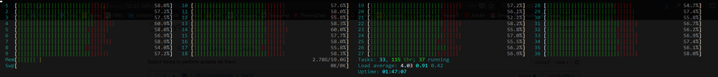

```python
from IPython.display import Image
fig = Image(filename=('/home/tim/e63-coursework/hw12/img/p0_htop.png'))
fig
```

# Problem 1 (45%)

Please find attached 2 files from Google’s tutorials sets. I used file *mnist2.py* for preparation of my notes. If you read the file carefully you will see that you can run it in at least two modes. The way it is setup now it selects one learning rate and one particular neural network architecture and generates TensorBoard graph in a particular directory. One problem with this script is that its accuracy is surprisingly low. Such complex architecture and so many lines of code and we get 70% or lower accuracy. We expected more from Convolutional Neural Networks. File *cnn_mnist.py* is practically the same, at least it does all the same things, creates similar architecture, sets the same or similar parameters, but does a much better job. Its accuracy is in high 90%-s.

**Question:** Run two files, compare results and then fix the first file *(mnist.py)* based on what you saw in file *cnn_mnist.py*.

**mnist2.py**

The first step is to run the *mnist2.py* file.

```python
%run /home/tim/e63-coursework/hw12/mnist2.py
```

```
Successfully downloaded train-images-idx3-ubyte.gz 9912422 bytes.
Extracting log3/data/train-images-idx3-ubyte.gz
Successfully downloaded train-labels-idx1-ubyte.gz 28881 bytes.
Extracting log3/data/train-labels-idx1-ubyte.gz
Successfully downloaded t10k-images-idx3-ubyte.gz 1648877 bytes.
Extracting log3/data/t10k-images-idx3-ubyte.gz
Successfully downloaded t10k-labels-idx1-ubyte.gz 4542 bytes.
Extracting log3/data/t10k-labels-idx1-ubyte.gz
Starting run for lr_1E-04conv2fc2
```

Next I'm running tensorgraph to visualize the results.

```
tensorboard --logdir=log3/lr_1E-04conv2fc2
```

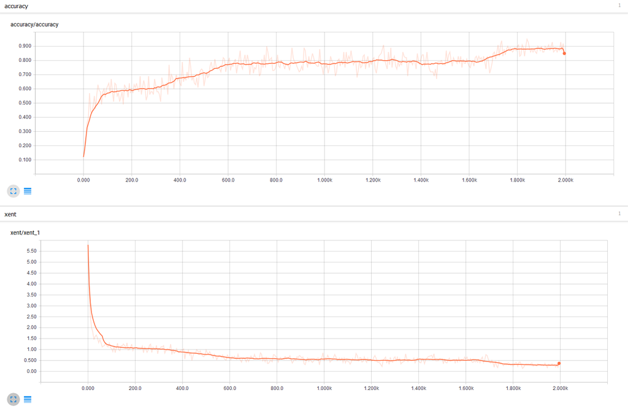

```python
fig = Image(filename=('/home/tim/e63-coursework/hw12/img/p1_1.png'))
fig
```

The above plot shows, that accuracy rate is at 85%. This accuracy rate is a bit higher than descibed in the problem description. Nevertheless, with such complex architecture and so many lines of code and we would expect a higher rate.

**cnn_mnist.py**

We can also run the *cnn_mnist.py* model

```python
%run /home/tim/e63-coursework/hw12/cnn_mnist.py
```

```
Successfully downloaded train-images-idx3-ubyte.gz 9912422 bytes.
Extracting temp/train-images-idx3-ubyte.gz
Successfully downloaded train-labels-idx1-ubyte.gz 28881 bytes.
Extracting temp/train-labels-idx1-ubyte.gz
Successfully downloaded t10k-images-idx3-ubyte.gz 1648877 bytes.
Extracting temp/t10k-images-idx3-ubyte.gz
Successfully downloaded t10k-labels-idx1-ubyte.gz 4542 bytes.
Extracting temp/t10k-labels-idx1-ubyte.gz
Generation # 5. Train Loss: 2.25. Train Acc (Test Acc): 20.00 (23.60)
Generation # 10. Train Loss: 2.07. Train Acc (Test Acc): 29.00 (31.60)
Generation # 15. Train Loss: 1.94. Train Acc (Test Acc): 44.00 (52.40)
Generation # 20. Train Loss: 1.57. Train Acc (Test Acc): 65.00 (57.20)
Generation # 25. Train Loss: 1.40. Train Acc (Test Acc): 62.00 (66.60)
Generation # 30. Train Loss: 1.08. Train Acc (Test Acc): 72.00 (75.40)
Generation # 35. Train Loss: 0.84. Train Acc (Test Acc): 77.00 (78.00)
Generation # 40. Train Loss: 0.65. Train Acc (Test Acc): 84.00 (83.00)
Generation # 45. Train Loss: 0.57. Train Acc (Test Acc): 82.00 (85.00)
Generation # 50. Train Loss: 0.31. Train Acc (Test Acc): 94.00 (86.60)
Generation # 55. Train Loss: 0.47. Train Acc (Test Acc): 86.00 (86.00)
Generation # 60. Train Loss: 0.32. Train Acc (Test Acc): 90.00 (88.20)
Generation # 65. Train Loss: 0.49. Train Acc (Test Acc): 83.00 (88.60)
Generation # 70. Train Loss: 0.44. Train Acc (Test Acc): 89.00 (90.20)
Generation # 75. Train Loss: 0.30. Train Acc (Test Acc): 91.00 (90.80)
Generation # 80. Train Loss: 0.21. Train Acc (Test Acc): 93.00 (87.80)
Generation # 85. Train Loss: 0.39. Train Acc (Test Acc): 89.00 (90.40)
Generation # 90. Train Loss: 0.37. Train Acc (Test Acc): 89.00 (90.00)
Generation # 95. Train Loss: 0.24. Train Acc (Test Acc): 94.00 (89.80)
Generation # 100. Train Loss: 0.36. Train Acc (Test Acc): 89.00 (91.40)
Generation # 105. Train Loss: 0.34. Train Acc (Test Acc): 92.00 (90.60)
Generation # 110. Train Loss: 0.41. Train Acc (Test Acc): 88.00 (90.20)
Generation # 115. Train Loss: 0.21. Train Acc (Test Acc): 95.00 (91.20)
Generation # 120. Train Loss: 0.37. Train Acc (Test Acc): 89.00 (91.80)
Generation # 125. Train Loss: 0.32. Train Acc (Test Acc): 91.00 (92.00)
Generation # 130. Train Loss: 0.33. Train Acc (Test Acc): 88.00 (93.00)
Generation # 135. Train Loss: 0.38. Train Acc (Test Acc): 93.00 (94.00)
Generation # 140. Train Loss: 0.30. Train Acc (Test Acc): 94.00 (91.20)
Generation # 145. Train Loss: 0.27. Train Acc (Test Acc): 90.00 (91.80)
Generation # 150. Train Loss: 0.18. Train Acc (Test Acc): 94.00 (93.00)
Generation # 155. Train Loss: 0.33. Train Acc (Test Acc): 89.00 (93.40)
Generation # 160. Train Loss: 0.20. Train Acc (Test Acc): 95.00 (90.20)
```

[output cut: 53 more lines]

```
Generation # 430. Train Loss: 0.10. Train Acc (Test Acc): 98.00 (94.80)
Generation # 435. Train Loss: 0.12. Train Acc (Test Acc): 98.00 (95.40)
Generation # 440. Train Loss: 0.20. Train Acc (Test Acc): 93.00 (94.00)
Generation # 445. Train Loss: 0.26. Train Acc (Test Acc): 91.00 (94.00)
Generation # 450. Train Loss: 0.10. Train Acc (Test Acc): 97.00 (93.80)
Generation # 455. Train Loss: 0.16. Train Acc (Test Acc): 93.00 (96.20)
Generation # 460. Train Loss: 0.08. Train Acc (Test Acc): 99.00 (96.40)
Generation # 465. Train Loss: 0.14. Train Acc (Test Acc): 97.00 (95.60)
Generation # 470. Train Loss: 0.20. Train Acc (Test Acc): 94.00 (96.00)
Generation # 475. Train Loss: 0.07. Train Acc (Test Acc): 97.00 (97.20)
Generation # 480. Train Loss: 0.12. Train Acc (Test Acc): 96.00 (95.60)
Generation # 485. Train Loss: 0.06. Train Acc (Test Acc): 98.00 (96.60)
Generation # 490. Train Loss: 0.12. Train Acc (Test Acc): 96.00 (97.00)
Generation # 495. Train Loss: 0.12. Train Acc (Test Acc): 96.00 (96.40)
Generation # 500. Train Loss: 0.11. Train Acc (Test Acc): 97.00 (96.40)
```

The above output shows, that the accuracy rate on test data lies at 95%. As described in the problem statment, this value is better than the result from the *mnist2.py* model.

**Comparison**

When comparing the two codes we can see that there are a lot of differences between them:

- Different Learning rates
- Initialization values for the convolution layers
- Dimension of the filters
- The Optimization algorithm (Adam vs. Momentum)
- Number of features in the first layer of convolution
- Number of features in the second layer of convolution
- Number of features in the input to first fully connected layer
- Number of features in the output of first fully connected layer

However, a likely culprit is that the *dropout* in order to avoid overfitting is missing in the *mnist2.py* script. That means the *mnist2.py* could be overfitting the data and the accuracy can't get into the same heights as the *cnn_mnist.py* script. I did fix this with the following lines of code:

First on line 61 I constructed a placeholder for the dropout.

```
keep_prob = tf.placeholder(tf.float32)
```

Next on line 79 I applied the dropout.

```
fc1_drop = tf.nn.dropout(fc1, keep_prob)
logits = fc_layer(fc1_drop, 1024, 10, "fc2")
```

Then on line 124 and 131 I'm feeding the probabilities:

```
[train_accuracy, s] = sess.run([accuracy, summ],
                               feed_dict={x: batch[0],y: batch[1],
                                          keep_prob: 1.0})
sess.run(train_step, feed_dict={x: batch[0],
                                y: batch[1],
                                keep_prob: 0.5})
```

**Note:** I also fixed the log file location inside the script. The fixed working code can be found in the *p1_mnist2.py* file.

**Question:** Capture the Accuracy and Cross Entropy (summary) graphs from the corrected version of *mnist2.py* and provide working and fixed version of that file.

```python
%run /home/tim/e63-coursework/hw12/p1_mnist2.py
```

```
Successfully downloaded train-images-idx3-ubyte.gz 9912422 bytes.
Extracting log3_fixeddata/train-images-idx3-ubyte.gz
Successfully downloaded train-labels-idx1-ubyte.gz 28881 bytes.
Extracting log3_fixeddata/train-labels-idx1-ubyte.gz
Successfully downloaded t10k-images-idx3-ubyte.gz 1648877 bytes.
Extracting log3_fixeddata/t10k-images-idx3-ubyte.gz
Successfully downloaded t10k-labels-idx1-ubyte.gz 4542 bytes.
Extracting log3_fixeddata/t10k-labels-idx1-ubyte.gz
Starting run for lr_1E-04conv2fc2
```

Next I'm running tensorgraph to visualize the results.

```
tensorboard --logdir=log3_fixedlr_1E-04conv2fc2
```

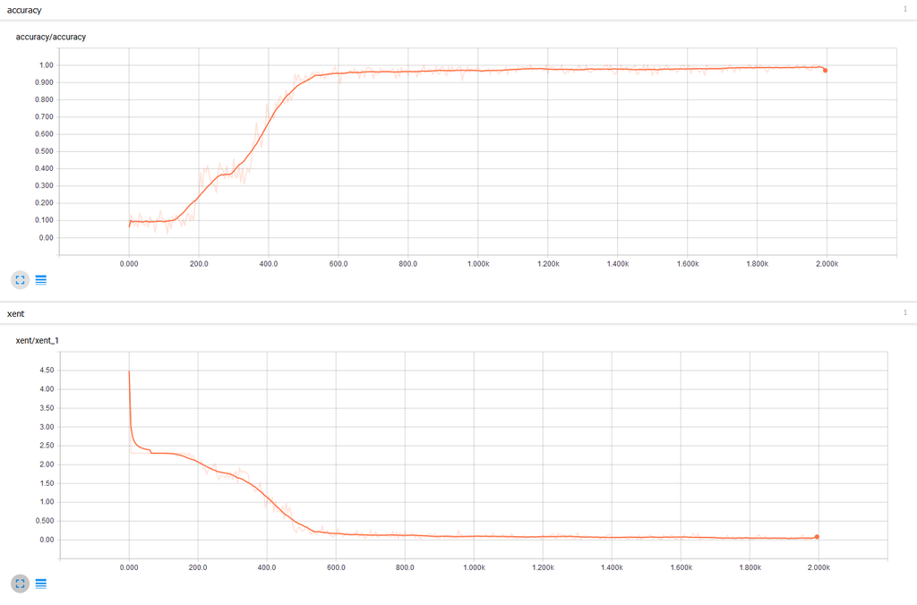

```python
fig = Image(filename=('/home/tim/e63-coursework/hw12/img/p1_3.png'))
fig
```

With the fixed script the accuracy rate heavily increases and the cross entropy rate decreases. With an accuracy rate of 97% I'm really happy and leave the model be. The model graph looks as follows:

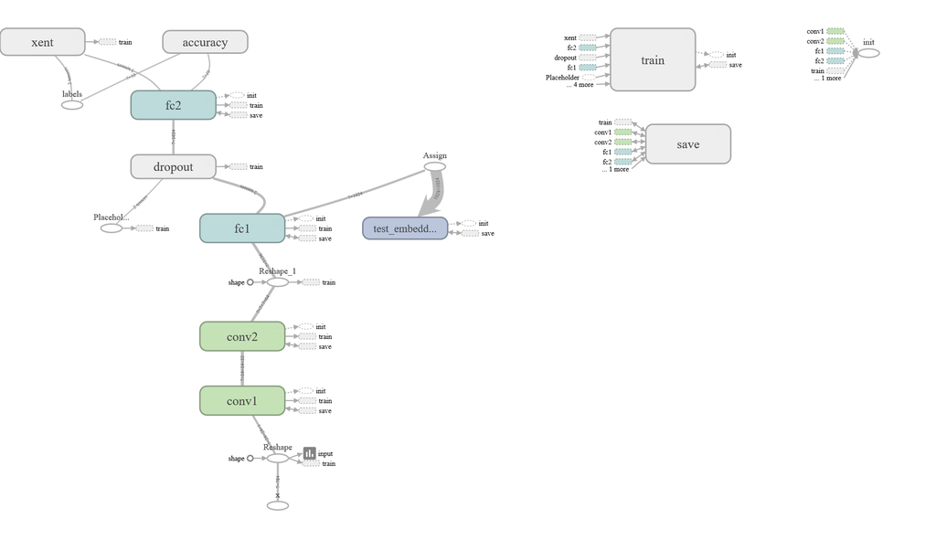

```python
fig = Image(filename=('/home/tim/e63-coursework/hw12/img/p1_4.png'))
fig
```

# Problem 2 (20%)

**Question:** Run a corrected version of *mnist2.py* for 4 different architectures (2 conv, 1 conv, 2 fully connected, 1 fully connected layer) and 3 values of the learning rate. As one learning rate choose the one you selected in Problem 1 and then add one smaller and one larger learning rate around that one.

First I'm starting adapting the *mnist2.py* script. All I'm doing is to change the *main()* function at the end of the script. The number of convolutional layers, the number of FC layers and the following learning rates are beeing set: 1E-03 (1'000), 1E-04 (10'000), 1E-05 (100'000). The results of this are saved in the *p2_mnist2.py* script.

With the following command we're running the *p2_mnist2.py* script:

```python
%run /home/tim/e63-coursework/hw12/p2_mnist2.py
```

```
Successfully downloaded train-images-idx3-ubyte.gz 9912422 bytes.
Extracting log3/data/train-images-idx3-ubyte.gz
Successfully downloaded train-labels-idx1-ubyte.gz 28881 bytes.
Extracting log3/data/train-labels-idx1-ubyte.gz
Successfully downloaded t10k-images-idx3-ubyte.gz 1648877 bytes.
Extracting log3/data/t10k-images-idx3-ubyte.gz
Successfully downloaded t10k-labels-idx1-ubyte.gz 4542 bytes.
Extracting log3/data/t10k-labels-idx1-ubyte.gz
Starting run for lr_1E-03conv2fc2
Starting run for lr_1E-03conv1fc2
Starting run for lr_1E-03conv2fc1
Starting run for lr_1E-03conv1fc1
Starting run for lr_1E-04conv2fc2
Starting run for lr_1E-04conv1fc2
Starting run for lr_1E-04conv2fc1
Starting run for lr_1E-04conv1fc1
Starting run for lr_1E-05conv2fc2
Starting run for lr_1E-05conv1fc2
Starting run for lr_1E-05conv2fc1
Starting run for lr_1E-05conv1fc1
```

**Question:** Please capture an image of “colorful” T-SNE Embedding.

In order to have a look at the T-SNE Embedding, I'm running the following command:

```
tensorboard --logdir=log3/lr_1E-03conv2fc2
```

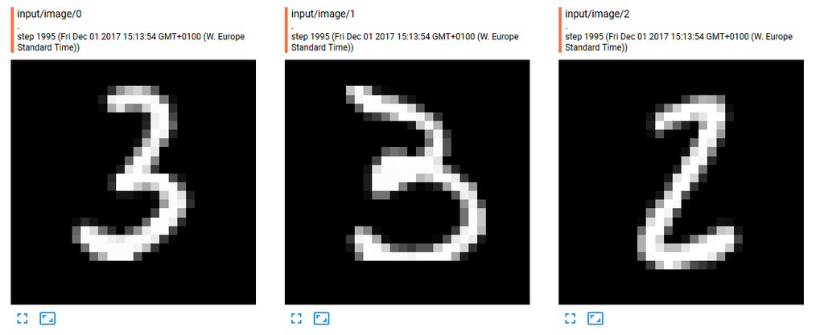

```python
from IPython.display import Image
fig = Image(filename=('/home/tim/e63-coursework/hw12/img/p2_img1.png'))
fig
```

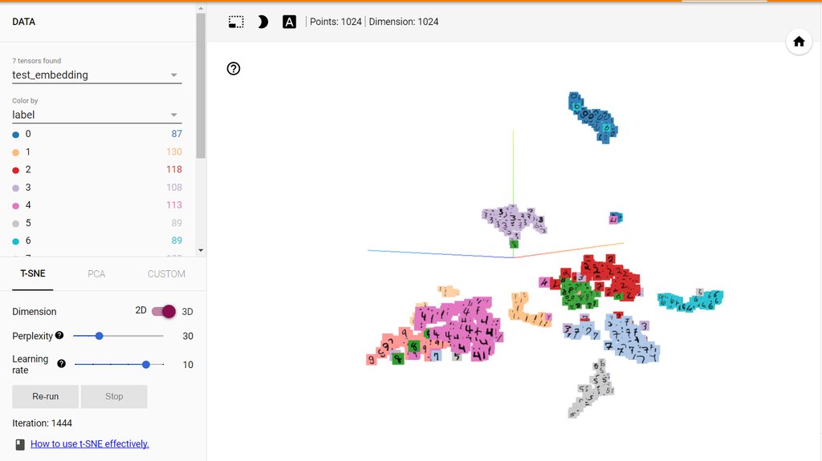

```python
fig = Image(filename=('/home/tim/e63-coursework/hw12/img/p2_img2.png'))
fig
```

**Question:** Capture Accuracy (summary) graphs and one of the Histograms to demonstrate to us that your code is working.

**Learning rate: 1E-03 (1'000)**

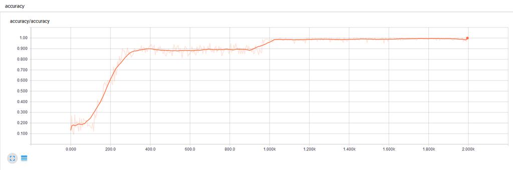

```python
fig = Image(filename=('/home/tim/e63-coursework/hw12/img/p2_conv2fc2_1e03_1.png'))
fig
```

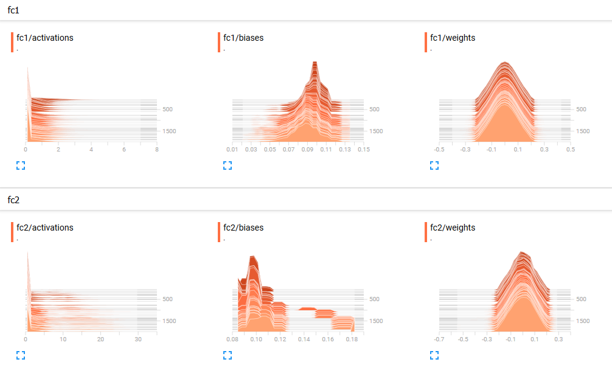

```python
fig = Image(filename=('/home/tim/e63-coursework/hw12/img/p2_conv2fc2_1e03_2.png'))
fig
```

**Learning rate: 1E-04 (10'000)**

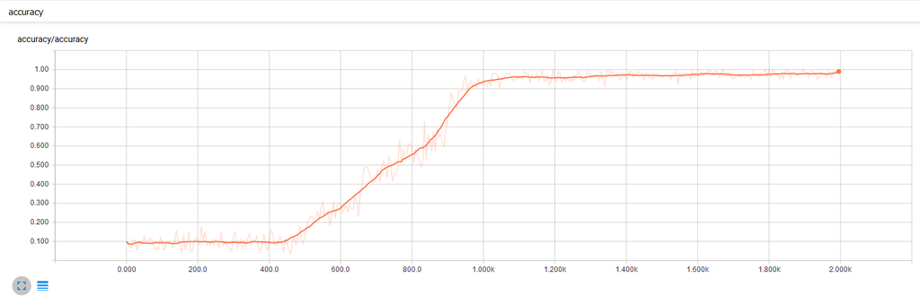

```python
fig = Image(filename=('/home/tim/e63-coursework/hw12/img/p2_conv2fc2_1e04_1.png'))
fig
```

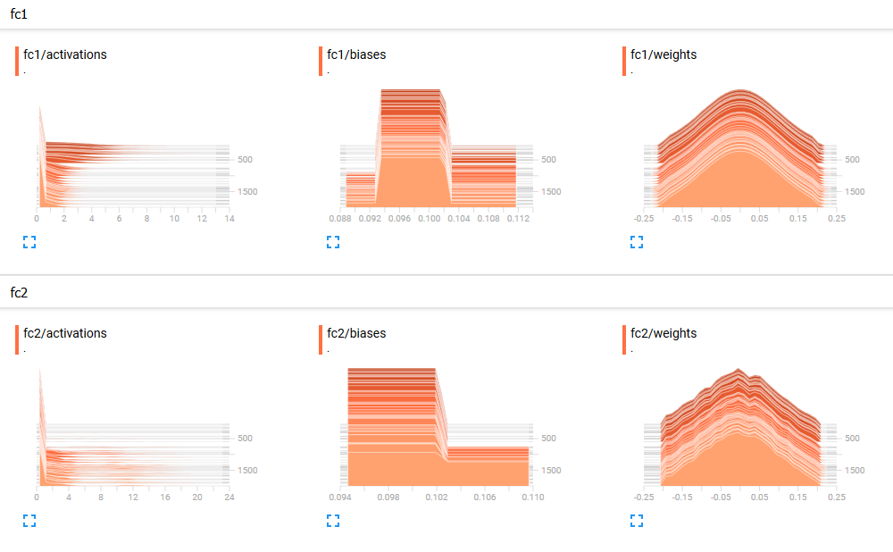

```python
fig = Image(filename=('/home/tim/e63-coursework/hw12/img/p2_conv2fc2_1e04_2.png'))
fig
```

**Learning rate: 1E-05 (100'000)**

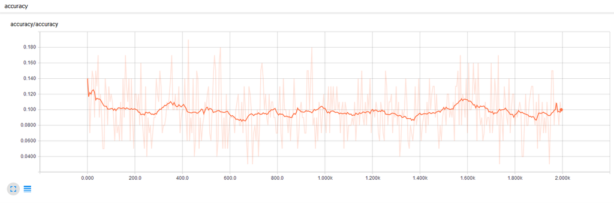

```python
fig = Image(filename=('/home/tim/e63-coursework/hw12/img/p2_conv2fc2_1e05_1.png'))
fig
```

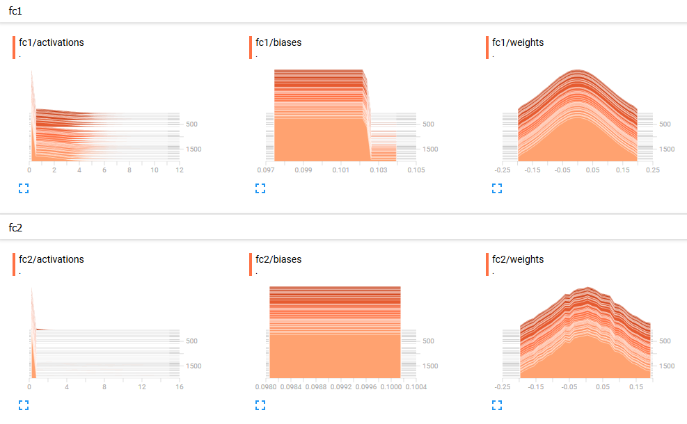

```python
fig = Image(filename=('/home/tim/e63-coursework/hw12/img/p2_conv2fc2_1e05_2.png'))
fig
```

**Question:** Collect execution times, final (smoothed) accuracies and final cross entropies for different models and provide tabulated presentation of the final results of different models.

| Architecture | Learning Rate | Execution Time | Smoothed Accuracy | Cross Entropy |
| --- | --- | --- | --- | --- |
| 2 Conv / 2 FC | 1E-03 | 3m 15s | 1.00 | 0.006 |
|  | 1E-04 | 3m 15s | 0.99 | 0.025 |
|  | 1E-05 | 3m 14s | 0.1 | 2.146 |
| 1 Conv / 1 FC | 1E-03 | 2m 38s | 0.29 | 1.641 |
|  | 1E-04 | 2m 40s | 0.39 | 1.787 |
|  | 1E-05 | 2m 41s | 0.78 | 0.842 |
| 2 Conv / 1 FC | 1E-03 | 3m 54s | 0.07 | 2.303 |
|  | 1E-04 | 3m 49s | 1.00 | 0.035 |
|  | 1E-05 | 3m 47s | 0.92 | 0.367 |
| 1 Conv / 2 FC | 1E-03 | 2m 38s | 0.29 | 2.400 |
|  | 1E-04 | 2m 40s | 0.37 | 1.787 |
|  | 1E-05 | 2m 41s | 0.78 | 0.842 |

The above table shows, that the 2 Conv / 2 FC model with a 1E-03 learning rate as well as the 2 Conv / 1 FC model with a 1E-04 learning rate perform the best with a smoothed accuracy of 1.00. Looking additionally at the cross entropy the 2 Conv 2 FC model with a 1E-03 learning rate performs the best.

# Problem 3 (35%)

**Question:** Modify file *cnn_mnist.py* so that it publishes its summaries to the TensorBoard. Describe changes you are making.

I adapted in the the above file the accuracy calculations. This is beeing done on line 119 (see code addition below)

```
cor_prediction = tf.equal(tf.argmax(model_output, 1),
                          tf.cast(y_target, tf.int64))
accuracy = tf.reduce_mean(tf.cast(cor_prediction,
                                  tf.float32))
tf.summary.scalar("accuracy", accuracy)
```

Furthermore, the loss function is beeing declared on line 103:

```
tf.summary.scalar('loss', loss)
```

Following that the summaries can be merged and the writer is set to the *question3* directory on line 133.

```
writer = tf.summary.FileWriter('./question3', sess.graph)
merged = tf.summary.merge_all()
```

Finally, the summary session is added to the writer on the lines 151 onwards:

```
_, s = sess.run([train_step, merged], feed_dict=train_dict)
writer.add_summary(s, i)
temp_train_loss,temp_train_acc, temp_train_preds = sess.run([loss,
                                                             accuracy,
                                                             prediction],
                                                            feed_dict=train_dict)
```

The overall working script can be found in the *p3_cnn_mnist.py* file. Having adapted the script we can run in with the following line:

```python
%run /home/tim/e63-coursework/hw12/p3_cnn_mnist.py
```

```
Successfully downloaded train-images-idx3-ubyte.gz 9912422 bytes.
Extracting temp/train-images-idx3-ubyte.gz
Successfully downloaded train-labels-idx1-ubyte.gz 28881 bytes.
Extracting temp/train-labels-idx1-ubyte.gz
Successfully downloaded t10k-images-idx3-ubyte.gz 1648877 bytes.
Extracting temp/t10k-images-idx3-ubyte.gz
Successfully downloaded t10k-labels-idx1-ubyte.gz 4542 bytes.
Extracting temp/t10k-labels-idx1-ubyte.gz
Generation # 5. Train Loss: 2.24. Train Acc (Test Acc): 0.19 (13.40)
Generation # 10. Train Loss: 2.18. Train Acc (Test Acc): 0.23 (20.40)
Generation # 15. Train Loss: 2.03. Train Acc (Test Acc): 0.28 (30.20)
Generation # 20. Train Loss: 2.01. Train Acc (Test Acc): 0.40 (45.40)
Generation # 25. Train Loss: 1.80. Train Acc (Test Acc): 0.56 (59.00)
Generation # 30. Train Loss: 1.44. Train Acc (Test Acc): 0.76 (68.60)
Generation # 35. Train Loss: 1.20. Train Acc (Test Acc): 0.70 (74.40)
Generation # 40. Train Loss: 0.81. Train Acc (Test Acc): 0.82 (72.60)
Generation # 45. Train Loss: 0.73. Train Acc (Test Acc): 0.81 (77.80)
Generation # 50. Train Loss: 0.56. Train Acc (Test Acc): 0.80 (81.00)
Generation # 55. Train Loss: 0.54. Train Acc (Test Acc): 0.79 (83.00)
Generation # 60. Train Loss: 0.50. Train Acc (Test Acc): 0.87 (83.20)
Generation # 65. Train Loss: 0.50. Train Acc (Test Acc): 0.83 (86.40)
Generation # 70. Train Loss: 0.42. Train Acc (Test Acc): 0.87 (83.60)
Generation # 75. Train Loss: 0.30. Train Acc (Test Acc): 0.91 (87.40)
Generation # 80. Train Loss: 0.40. Train Acc (Test Acc): 0.84 (87.60)
Generation # 85. Train Loss: 0.41. Train Acc (Test Acc): 0.87 (88.20)
Generation # 90. Train Loss: 0.43. Train Acc (Test Acc): 0.90 (89.40)
Generation # 95. Train Loss: 0.37. Train Acc (Test Acc): 0.91 (87.60)
Generation # 100. Train Loss: 0.39. Train Acc (Test Acc): 0.90 (89.80)
Generation # 105. Train Loss: 0.26. Train Acc (Test Acc): 0.93 (90.40)
Generation # 110. Train Loss: 0.29. Train Acc (Test Acc): 0.90 (91.00)
Generation # 115. Train Loss: 0.28. Train Acc (Test Acc): 0.90 (91.20)
Generation # 120. Train Loss: 0.31. Train Acc (Test Acc): 0.91 (90.80)
Generation # 125. Train Loss: 0.40. Train Acc (Test Acc): 0.87 (92.80)
Generation # 130. Train Loss: 0.31. Train Acc (Test Acc): 0.91 (92.60)
Generation # 135. Train Loss: 0.21. Train Acc (Test Acc): 0.95 (91.80)
Generation # 140. Train Loss: 0.21. Train Acc (Test Acc): 0.94 (91.40)
Generation # 145. Train Loss: 0.21. Train Acc (Test Acc): 0.92 (90.40)
Generation # 150. Train Loss: 0.37. Train Acc (Test Acc): 0.87 (91.40)
Generation # 155. Train Loss: 0.38. Train Acc (Test Acc): 0.90 (93.20)
Generation # 160. Train Loss: 0.27. Train Acc (Test Acc): 0.92 (88.20)
```

[output cut: 53 more lines]

```
Generation # 430. Train Loss: 0.09. Train Acc (Test Acc): 0.98 (95.00)
Generation # 435. Train Loss: 0.12. Train Acc (Test Acc): 0.97 (96.60)
Generation # 440. Train Loss: 0.06. Train Acc (Test Acc): 0.98 (94.40)
Generation # 445. Train Loss: 0.11. Train Acc (Test Acc): 0.95 (97.20)
Generation # 450. Train Loss: 0.10. Train Acc (Test Acc): 0.96 (95.40)
Generation # 455. Train Loss: 0.10. Train Acc (Test Acc): 0.96 (97.00)
Generation # 460. Train Loss: 0.17. Train Acc (Test Acc): 0.94 (93.80)
Generation # 465. Train Loss: 0.10. Train Acc (Test Acc): 0.97 (96.20)
Generation # 470. Train Loss: 0.27. Train Acc (Test Acc): 0.93 (96.00)
Generation # 475. Train Loss: 0.11. Train Acc (Test Acc): 0.96 (97.00)
Generation # 480. Train Loss: 0.07. Train Acc (Test Acc): 0.99 (97.20)
Generation # 485. Train Loss: 0.06. Train Acc (Test Acc): 0.99 (96.00)
Generation # 490. Train Loss: 0.18. Train Acc (Test Acc): 0.96 (97.20)
Generation # 495. Train Loss: 0.15. Train Acc (Test Acc): 0.94 (96.00)
Generation # 500. Train Loss: 0.21. Train Acc (Test Acc): 0.94 (96.60)
```

**Question:** Provide images of accuracy and loss summaries as captured by the Tensor Board.

We can visualize the tensorgraph images with the following command:

```
tensorboard --logdir=question3
```

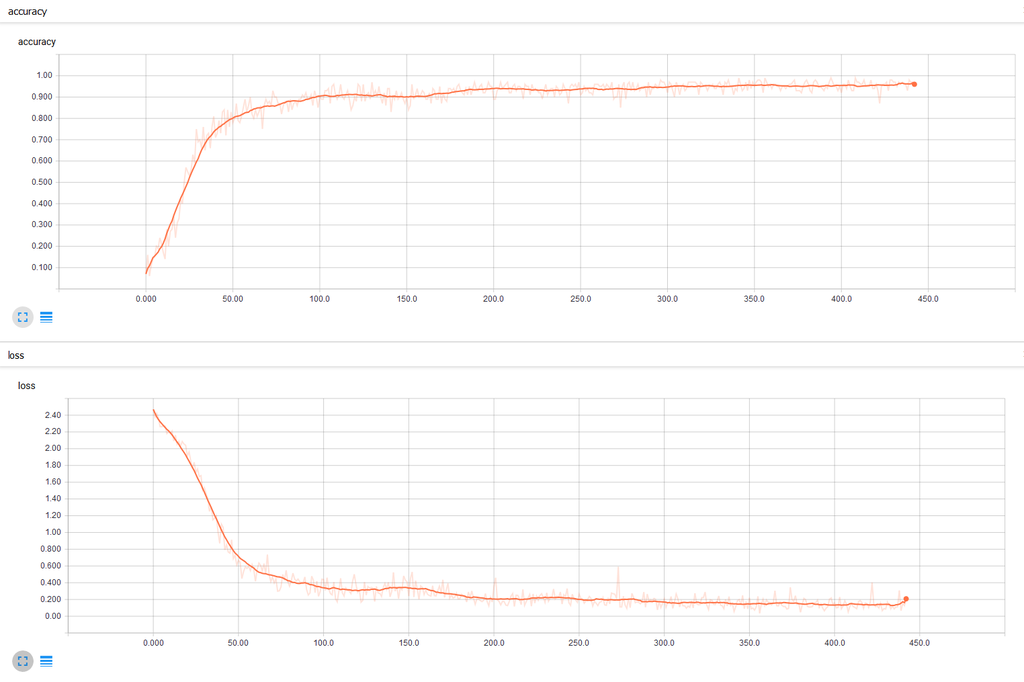

```python
fig = Image(filename=('/home/tim/e63-coursework/hw12/img/p3_1.png'))
fig
```

**Question:** Provide the Graph of your model. Describe the differences if any between the graph of this program and the graph generated by *mnist2.py* script running with 2 convolutional and 2 fully connected layers.

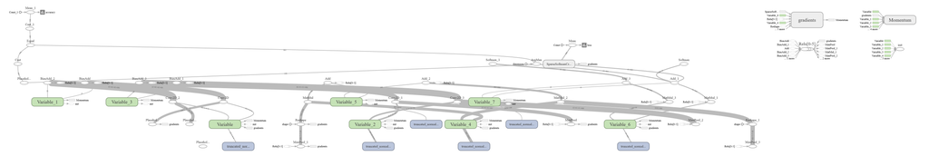

```python
fig = Image(filename=('/home/tim/e63-coursework/hw12/img/p3_2.png'))
fig
```